# Conjoint Analysis of Chocolate Preferences

Calvin Yen

2/12/2022

## Exploratory Data Analysis

87 respondents participated in a conjoint study to understand consumer chocolate preferences. Five product attributes were studied:

- kind - chocolate type (milk, walnut, delicacies, dark)
- price - low, average, high
- packing - product packaging (paperback, hardback)
- weight - light, middle, heavy
- calorie - caloric content of the chocolate (little, much)

The chocolate dataset comprises five data frames:

- clevn - vector of attribute level names
- cpref - raw vector of profile preferences for all 87 respondents (87 respondents with ratings for each of the 16 profiles)
- cprefm - matrix of profile preferences (87 respondents with ratings for each of the 16 profiles)
- cprof - matrix of profiles (16 profiles with 5 attributes each)
- csimp - matrix of simulation profiles

```r
data(chocolate, package='conjoint')

# Attribute levels
dim(clevn)
```

```
## [1] 14  1
```

```r
head(clevn)
```

```
##       levels
## 1       milk
## 2     walnut
## 3 delicaties
## 4       dark
## 5        low
## 6    average
```

```r
# Respondent profile preferences - raw
dim(cpref)
```

```
## [1] 1392    1
```

```r
head(cpref)
```

```
##   pref
## 1   14
## 2   15
## 3    5
## 4    2
## 5    1
## 6   11
```

```r
# Respondent profile preferences
dim(cprefm)
```

```
## [1] 87 16
```

```r
head(cprefm)
```

```
##   profile1 profile2 profile3 profile4 profile5 profile6 profile7 profile8
## 1       14       15        5        2        1       11        3       10
## 2       16       15        7       14        6        3       12        8
## 3        7        8        9       13       14        1       16        2
## 4        9       10       11       14       15        8        3        2
## 5        7        1        4       12       16        8       15        2
## 6       14       16       15        7        8        9       11       10
##   profile9 profile10 profile11 profile12 profile13 profile14 profile15
## 1       16        13        12         7         6         9         4
## 2        1         4        13         9         5        10        11
## 3        5         6         4        10        11         3        15
## 4        7         1         4         6         5        12        16
## 5        3         5        11        14        10         6        13
## 6       13        12         1         3         2         5         6
##   profile16
## 1         8
## 2         2
## 3        12
## 4        13
## 5         9
## 6         4
```

```r
# Product profiles
dim(cprof)
```

```
## [1] 16  5
```

```r
head(cprof)
```

```
##   kind price packing weight calorie
## 1    3     3       1      2       1
## 2    3     2       2      1       2
## 3    2     1       2      1       1
## 4    4     1       2      1       1
## 5    4     2       2      2       1
## 6    1     1       2      2       2
```

```r
# Simulated product profiles
dim(csimp)
```

```
## [1] 4 5
```

```r
head(csimp)
```

```
##   kind price packing weight calorie
## 1    4     1       2      2       1
## 2    1     3       1      1       2
## 3    2     2       1      3       1
## 4    3     1       1      1       1
```

## Partworth Estimation

### Individual-level estimation

Partworth utilities were first estimated at an individual level. Profiles were then predicted for each individual by taking the profile with the highest utility. Profile selections were correctly predicted for 41 of 87 (47%) of respondents.

```r
# Compute partworth utilities for each individual
indiv_partutilities <- caPartUtilities(y=cprefm, x=cprof, z=clevn)
head(indiv_partutilities)
```

```
##      intercept  milk walnut delicaties  dark    low average   high
## [1,]     8.583  2.00  -2.00       6.00 -6.00  0.000  -0.250  0.250
## [2,]     8.500  0.00  -2.75       0.50  2.25 -2.667   0.333  2.333
## [3,]     8.625 -6.00   2.00      -2.00  6.00 -0.667  -0.167  0.833
## [4,]     8.208 -2.00   0.25      -1.75  3.50  2.333   0.333 -2.667
## [5,]     8.833 -1.75   0.75      -4.50  5.50 -1.333  -0.583  1.917
## [6,]     8.292 -2.25  -2.50       5.25 -0.50  0.500   0.875 -1.375
##      paperback hardback  light middle  heavy little   much
## [1,]     0.000    0.000 -0.333 -0.083  0.417 -1.000  1.000
## [2,]     0.500   -0.500  2.667 -1.083 -1.583  0.250 -0.250
## [3,]     0.375   -0.375  0.167  0.042 -0.208 -0.375  0.375
## [4,]    -0.750    0.750 -1.167  2.458 -1.292  0.125 -0.125
## [5,]     0.375   -0.375  0.000  1.500 -1.500 -0.750  0.750
## [6,]    -0.375    0.375  0.333  0.333 -0.667  0.625 -0.625
```

```r
# Compute total utility for each individual
indiv_totalutilities <- caTotalUtilities(y=cprefm, x=cprof)
head(indiv_totalutilities)
```

```
##        [,1]   [,2]   [,3]   [,4]   [,5]   [,6]   [,7]  [,8]   [,9]  [,10]
## [1,] 13.750 15.000  5.250  1.250  1.250 11.500  3.500 9.750 16.000 13.250
## [2,] 11.000 11.250  5.500 10.500  9.750  4.000 16.000 8.000  4.000  9.750
## [3,]  7.500  6.625  9.375 13.375 13.750  2.000 16.375 2.250  5.750  6.125
## [4,]  5.625  6.250 10.500 13.750 15.375 11.625  7.000 4.625  8.125  7.000
## [5,]  7.375  4.125  7.125 11.875 14.125  7.625 17.375 4.625  1.875  2.625
## [6,] 12.750 14.500  7.625  9.625 10.000  6.625  5.750 6.500 13.125 14.625
##       [,11]  [,12]  [,13] [,14]  [,15]  [,16]
## [1,] 11.500  7.000  6.250 9.250  4.000  7.500
## [2,] 12.750  9.000  6.250 9.250  6.750  2.250
## [3,]  3.625 11.375 10.500 2.125 14.500 10.750
## [4,]  3.000  6.750  5.375 6.750 11.875 12.375
## [5,]  9.375 10.125  8.875 5.375 12.625 10.875
## [6,]  4.750  6.000  4.750 7.125  6.625  5.625
```

```r
# Predict the profile chosen by each individual
indiv_profile_pred <- apply(indiv_totalutilities, 1, which.max)

# Find the profile most preferred by each individual
indiv_profile_actual <- apply(cprefm, 1, which.max)

# Find proportion of correct predictions
sum(indiv_profile_pred == indiv_profile_actual) / length(indiv_profile_actual)
```

```
## [1] 0.4712644
```

```r
# Determine attribute importances for first 10 individuals

attr_importances <- caImportance(y=cprefm[1,], cprof)
attr_importances <- data.frame(t(as.matrix(attr_importances)))
colnames(attr_importances) <- colnames(cprof)

num_profiles <- 10
for (i in 2:num_profiles) {
  attr_imp_i <- caImportance(y=cprefm[i,], cprof)
  attr_importances <- rbind(attr_importances, attr_imp_i)
}
attr_importances
```

```
##     kind price packing weight calorie
## 1  78.69  3.28    0.00   4.92   13.11
## 2  31.75 31.75    6.35  26.98    3.17
## 3  78.05  9.76    4.88   2.44    4.88
## 4  34.38 31.25    9.38  23.44    1.56
## 5  54.05 17.57    4.05  16.22    8.11
## 6  59.62 17.31    5.77   7.69    9.62
## 7  68.33 13.33    1.67  13.33    3.33
## 8  58.65 23.31    7.52   6.02    4.51
## 9  48.15 20.37   20.37   9.26    1.85
## 10 39.46 20.41    8.16  27.89    4.08
```

### Aggregate-level estimation

Partworth utilities were then estimated at an aggregate level. In this model, all individuals are assumed to have homogeneous preferences and hence share the same utility coefficients. Using the aggregate model, we find that profile 7 is the most desirable. 35 out of 87 (40%) respondents chose profile 7.

```r
# Compute partworth utilities at an aggregate level
# First method - use caUtilities function
agg_partutilities1 <- caUtilities(y=cprefm, x=cprof, z=clevn)
```

```
##
## Call:
## lm(formula = frml)
##
## Residuals:
##      Min       1Q   Median       3Q      Max
## -11,3305  -3,5546   0,4799   3,4799   9,8190
##
## Coefficients:
##                    Estimate Std. Error t value Pr(>|t|)
## (Intercept)         8,68487    0,12648  68,667  < 2e-16 ***
## factor(x$kind)1    -1,08908    0,19815  -5,496 4,62e-08 ***
## factor(x$kind)2    -0,73276    0,19815  -3,698 0,000226 ***
## factor(x$kind)3    -0,92241    0,19815  -4,655 3,55e-06 ***
## factor(x$price)1   -0,57088    0,15254  -3,743 0,000190 ***
## factor(x$price)2    0,11877    0,17887   0,664 0,506777
## factor(x$packing)1 -0,02874    0,11440  -0,251 0,801714
## factor(x$weight)1  -0,16858    0,15254  -1,105 0,269272
## factor(x$weight)2   0,17337    0,17887   0,969 0,332575
## factor(x$calorie)1 -0,64655    0,11440  -5,652 1,93e-08 ***
## ---
## Signif. codes:  0 '***' 0,001 '**' 0,01 '*' 0,05 '.' 0,1 ' ' 1
##
## Residual standard error: 4,268 on 1382 degrees of freedom
## Multiple R-squared:  0,1488, Adjusted R-squared:  0,1433
## F-statistic: 26,85 on 9 and 1382 DF,  p-value: < 2,2e-16
```

```r
# Second method - average individual partworth utilities
agg_partutilities2 <- apply(indiv_partutilities, 2, mean)
agg_partutilities2
```

```
##    intercept         milk       walnut   delicaties         dark
##  8.684862069 -1.089080460 -0.732758621 -0.922413793  2.744252874
##          low      average         high    paperback     hardback
## -0.570965517  0.118689655  0.452022989 -0.028735632  0.028735632
##        light       middle        heavy       little         much
## -0.168586207  0.173367816 -0.004793103 -0.646551724  0.646551724
```

```r
# Calculate estimated profile
# Dummy code the matrix of profiles
cprof_factor <- data.frame(lapply(cprof, as.factor))
cprof_dummyenc <- model.matrix(~., cprof_factor)

# Match attribute names between dummy-encoded profile matrix and utility coefficients
attr_names <- c('(Intercept)')
for (col in colnames(cprof)) {
  col_values <- unique(cprof[[col]])
  attr_name <- paste(col, sort(col_values), sep='')
  attr_names <- c(attr_names, attr_name)
}

names(agg_partutilities1) <- attr_names
agg_partutilities <- agg_partutilities1[colnames(cprof_dummyenc)]

# Multiply profile codes by utility coefficients to determine the utility of each profile
profile_utilities <- cprof_dummyenc %*% agg_partutilities
profile_utilities
```

```
##         [,1]
## 1   7.712644
## 2   8.387931
## 3   6.594828
## 4  10.071839
## 5  11.103448
## 6   7.873563
## 7  12.330460
## 8   7.034483
## 9   7.862069
## 10  6.347701
## 11  8.554598
## 12  8.520115
## 13  7.781609
## 14  6.181034
## 15 11.471264
## 16  8.172414
```

```r
# Find profile with the highest utility
best_profile <- which.max(profile_utilities)
best_profile
```

```
## [1] 7
```

```r
# Find proportion of respondents that chose the profile predicted by the model
sum(indiv_profile_actual == best_profile) / length(indiv_profile_actual)
```

```
## [1] 0.4022989
```

## Segmentation

```r
# Product attribute importances
caImportance(y=cprefm, x=cprof)
```

```
## [1] 56.79 16.42  5.43 10.61 10.75
```

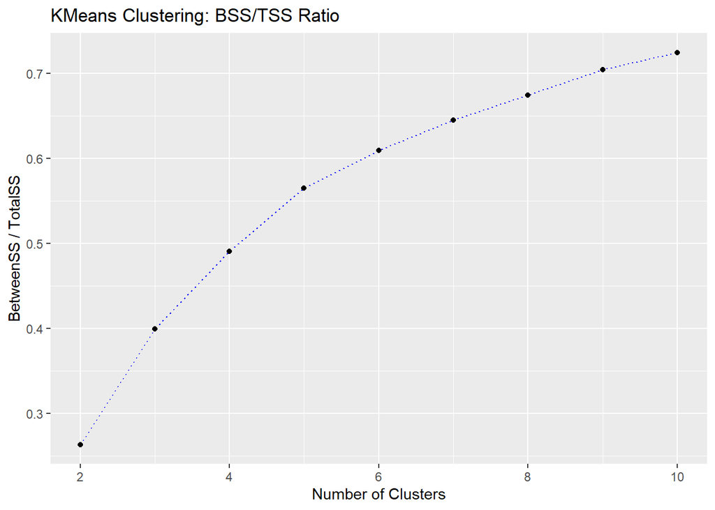

```r
# Try and evaluate K-Means with varying numbers of clusters
max_k <- 10
ss_ratios <- data.frame(numeric(0), numeric(0))

for (k in 2:max_k) {
  km <- kmeans(indiv_partutilities, centers=k, nstart=20)
  ss_ratio <- km$betweenss / km$totss
  ss_ratios <- rbind(ss_ratios, c(k, ss_ratio))
}

colnames(ss_ratios) <- c('num_clusters', 'ss_ratio')

# Plot SS ratios to find optimal number of clusters
ggplot(ss_ratios, aes(x=num_clusters, y=ss_ratio)) +
  geom_line(col='blue', linetype='dotted') +
  geom_point() +
  labs(title='KMeans Clustering: BSS/TSS Ratio',
       x='Number of Clusters',
       y='BetweenSS / TotalSS')
```

```r
best_k <- kmeans(indiv_partutilities, centers=5, nstart=20)

# Visualize clustering results
# Run PCA to reduce dimensions to 2D for cluster visualization
pca <- prcomp(indiv_partutilities)
summary(pca)
```

```
## Importance of components:
##                           PC1    PC2    PC3     PC4     PC5     PC6
## Standard deviation     4.4551 3.8908 3.2061 2.02640 1.69095 1.41905
## Proportion of Variance 0.3481 0.2655 0.1803 0.07201 0.05015 0.03532
## Cumulative Proportion  0.3481 0.6136 0.7938 0.86587 0.91601 0.95133
##                            PC7     PC8     PC9      PC10      PC11
## Standard deviation     1.08261 0.98351 0.79747 0.0004591 0.0004119
## Proportion of Variance 0.02055 0.01696 0.01115 0.0000000 0.0000000
## Cumulative Proportion  0.97188 0.98885 1.00000 1.0000000 1.0000000
##                             PC12      PC13     PC14     PC15
## Standard deviation     0.0002657 6.384e-16 2.48e-16 3.82e-17
## Proportion of Variance 0.0000000 0.000e+00 0.00e+00 0.00e+00
## Cumulative Proportion  1.0000000 1.000e+00 1.00e+00 1.00e+00
```

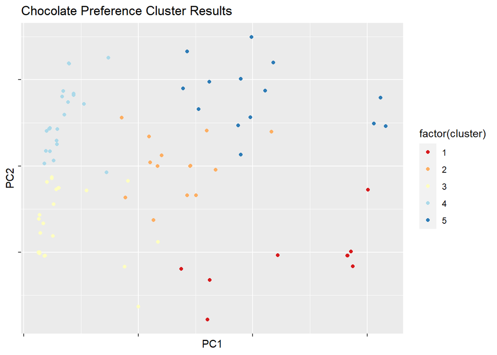

```r
pc_clusters <- data.frame(PC1=pca$x[, 'PC1'], PC2=pca$x[, 'PC2'], cluster=best_k$cluster)

ggplot(pc_clusters, aes(x=PC1, y=PC2)) +
  geom_point(aes(color=factor(cluster))) +
  labs(title='Chocolate Preference Cluster Results') +
  scale_color_brewer(palette='RdYlBu') +
  theme(axis.text=element_blank())
```

## Cluster-based Model

The results of the cluster analysis were used to build a cluster-based model–respondents’ chocolate preferences were predicted based on their cluster (i.e., segment).

```r
# Find utility coefficients for each segment
cluster_coef <- best_k$centers
cluster_coef
```

```
##   intercept       milk     walnut delicaties      dark        low
## 1  8.486111  3.1111111  3.2222222 -2.5000000 -3.833333 -0.1667778
## 2  9.047714 -0.8035714 -0.2321429 -0.3750000  1.410714 -2.2739286
## 3  8.567708  1.2291667 -2.0208333 -4.3020833  5.093750 -0.1597500
## 4  8.700308 -4.4615385 -0.8557692 -0.4711538  5.788462 -0.3975000
## 5  8.621929 -1.7857143 -1.3392857  4.5000000 -1.375000 -0.1549286
##       average       high   paperback    hardback       light     middle
## 1 -0.04177778  0.2082222  0.18055556 -0.18055556  0.22233333 -0.1387778
## 2 -0.19357143  2.4671429 -0.16071429  0.16071429  0.08335714  0.3422857
## 3  0.26212500 -0.1024583 -0.12500000  0.12500000 -0.11112500  0.3888750
## 4  0.07365385  0.3236538 -0.05769231  0.05769231 -0.40388462  0.3701538
## 5  0.37185714 -0.2174286  0.18750000 -0.18750000 -0.33335714 -0.5297857
##         heavy     little      much
## 1 -0.08322222 -0.5416667 0.5416667
## 2 -0.42557143 -2.2321429 2.2321429
## 3 -0.27779167 -0.2239583 0.2239583
## 4  0.03361538 -0.4567308 0.4567308
## 5  0.86307143 -0.2053571 0.2053571
```

```r
colnames(cluster_coef) <- attr_names
cluster_coef <- cluster_coef[, colnames(cluster_coef) %in% colnames(cprof_dummyenc)]

# Multiply profile codes by utility coefficients to determine the utility of each profile
cluster_prof_utilities <- cprof_dummyenc %*% t(cluster_coef)
cluster_prof_utilities
```

```
##            1         2         3         4         5
## 1   5.694778  9.089643  4.203167  8.408731 12.357357
## 2   6.527778 10.955357  4.765583  8.413346 13.178286
## 3  11.041667  4.553571  6.177042  6.644115  6.401500
## 4   3.986111  6.196429 13.291625 13.288346  6.365786
## 5   3.750000  8.535714 14.213500 14.533538  6.696143
## 6  11.652778  8.705357 10.374958  4.725846  6.169357
## 7   5.805889 15.080714 13.546917 14.807769  7.089500
## 8  11.110778  5.232071  9.432292  3.831731  8.053357
## 9   6.096889  8.366000  4.177083  8.379808 13.848000
## 10  5.680556  4.089286  3.645792  6.913346 12.615786
## 11 12.389222 13.187857  9.932333  4.673154  6.303786
## 12 12.611111 10.776786  6.796833  7.913346  7.714000
## 13 11.111111  8.786000  6.067792  7.803077  7.536000
## 14 11.291667  3.660714  9.177042  2.922962  6.330071
## 15  5.124667  9.830286 13.322917 14.524038  8.348000
## 16 12.125000  8.955357  6.874958  8.216231  6.990786
```

```r
# Find the profile that maximizes each segment's utility
cluster_profiles <- apply(cluster_prof_utilities, 2, which.max)
cluster_profiles
```

```
##  1  2  3  4  5
## 12  7  5  7  9
```

```r
cprefm$cluster <- best_k$cluster
cprefm$cluster_profile <- cluster_profiles[cprefm$cluster]

sum(indiv_profile_actual == cprefm$cluster_profile) / length(indiv_profile_actual)
```

```
## [1] 0.3678161
```